# Data Visualization 2024: Student Project (R)

Author

Affiliation

Zubeir El Ahmad

Deggendorf Institute of Technology

Published

June 27, 2024

# 1 General information

The final task comprises both visualization as well as short text exercises. To complete the final exam, you have to perform the following steps:

- Exercises have to be performed in an R Markdown file.
- Add your matriculation number to the R Markdown.
- Write R code to visualize the given data (see detailed instructions below).
- Include the code in the final file.
- Comment your code to describe what your code does.
- Recreate the shown example figures using the provided data.
- If required, add additional plots to the R Markdown file.
- Answer the questions posed in a few sentences.
- Export the final notebook to an html and upload it to iLearn (no other file formats are accepted).

# 2 Libraries

Install and load the libraries required to finish the tasks.

> **Note**: Installing and loading packages are two individual steps in R! Package installation needs to be executed only once, while package loading has to be performed every time you re-open your project.

# 3 TCGA expression data

The Cancer Genome Atlas (TCGA) is a comprehensive project that aims to catalog genetic mutations responsible for cancer using genome sequencing and bioinformatics. TCGA has collected and analyzed tumor and normal tissue samples from thousands of patients across more than 30 different types of cancer. The data generated by TCGA is publicly available, providing researchers with access to a rich resource for cancer research. This database includes information on somatic mutations, copy number variations, gene expression levels, and clinical data.

## 3.1 Load and prepare data

Download the “tcga_cancer.csv” and “tcga_cancer_labels.csv” datasets from iLearn and make yourself familiar with the data. Read in the files using the functions we discussed in class. To reproduce the plots presented below, you need to select the first 200 samples for gene 1 to gene 43.

## 3.2 Plotting

> **Note**: As discussed, pay attention to the size of the numbers/text in your plots. It is very important that everything is clearly and easily readable!

### 3.2.1 Expression distribution Gene1

Visualize the distribution of the expression values for Gene1 using a histogram. Remind yourself of what we learned about the bin width in a histogram and try out different values for this example. What do you think about the bin width chosen? Are there more appropriate values? Plot a second histogram with another bin width and give a short comment.

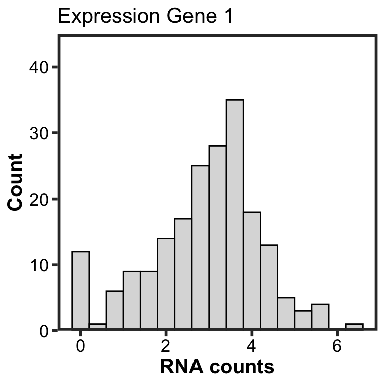

### 3.2.2 Gene expression correlation

Analyze the relationship between Gene1 and Gene12 of your table with the help of scatterplot. Add a linear regression line and include the pearson correlation coefficient to your plot. Briefly explain what correlation is and what your calculated coefficient tells you about the data. What is the grey area surrounding the regression line and what does it mean?

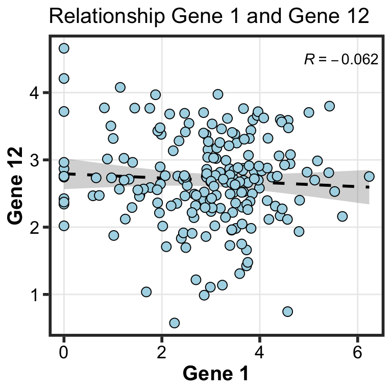

### 3.2.3 Class proportions

Stacked bar charts are a solid way to visualize proportions of a single variable. Generate such a bar chart displaying the relative proportion (percentage) of gene classes for our test dataset. In addition, add the absolute numbers for each class inside the individual bars.

Shortly comment if the coloring is a good choice. If yes, explain why. If not, what would you change?

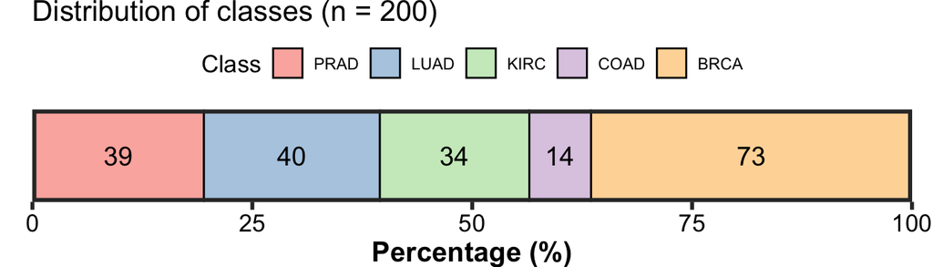

### 3.2.4 Combine the plots

Combine the individual plots to a single figure with the help of a package we used during the course. Add an appropriate labeling.

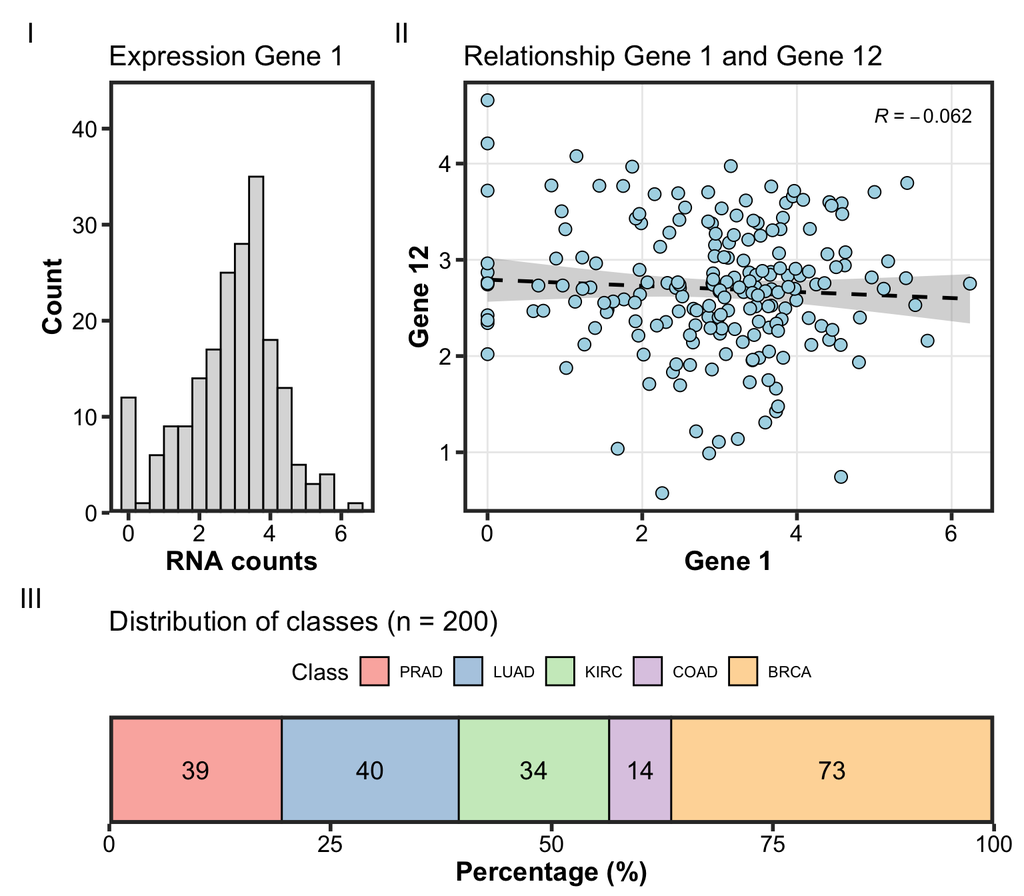

# 4 Human genome

GENCODE is a scientific project focused on producing a comprehensive and high-quality annotation of the human and mouse genomes. It aims to identify and classify all gene features, including protein-coding genes, non-coding RNAs, and pseudogenes. The project provides detailed information on gene structures, transcripts, and their functional elements, supporting research in genomics, biology, and medicine.

## 4.1 Load and prepare data

Download and read in the “hg38_genes.tsv” dataset from iLearn. It contains 20,000 randomly selected annotated genes from the GENCODE gtf file for the human genome (hg38).

You need to execute the following transformation steps before you can use the data for plotting:

- Filter for genes whose type is either “protein_coding”, “lncRNA”, “processsed_pseudogenes” or “transcribed_unprocessed_pseudogene”.
- Rename the group of “protein_coding” genes to “mRNA” and combine “processsed_pseudogenes” plus “transcribed_unprocessed_pseudogene” to a new group called “Pseudo”.
- Keep only genes with a length (distance between start and end) higher than 1,000 and lower or equal than 20,000.

## 4.2 Plotting

### 4.2.1 Gene count

Begin with summarizing the total count of genes per class represented by a classical bar chart. Use the newly formed categories and set an appropriate range of the scale.

> **Note**: Keep an eye on the order of classes on the x-axis. It is a common task to perform a rearrangement in order to optimize the visualization!

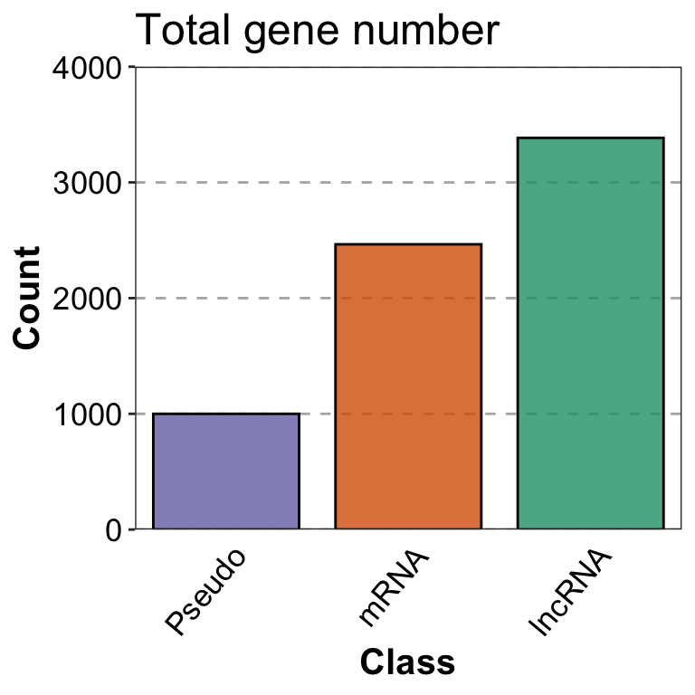

### 4.2.2 Length distribution

Take a look at how the gene length is distributed in each class with the help of an overlapping density plot. Additionally include vertical lines that represent the median gene length for each class.

What is your opinion on this plot type? Visualize the length distribution using another type of plot and comment on which of the two plots is more intuitive to understand/read according to you.

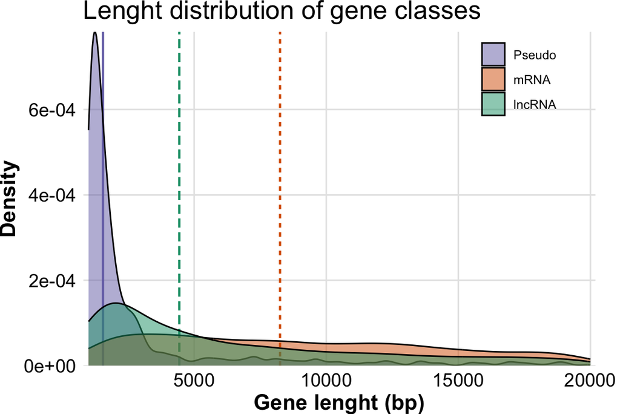

### 4.2.3 Include figure

This time, combine the plots, export the file, and include it as figure in the R Markdown file. Add a figure legend.

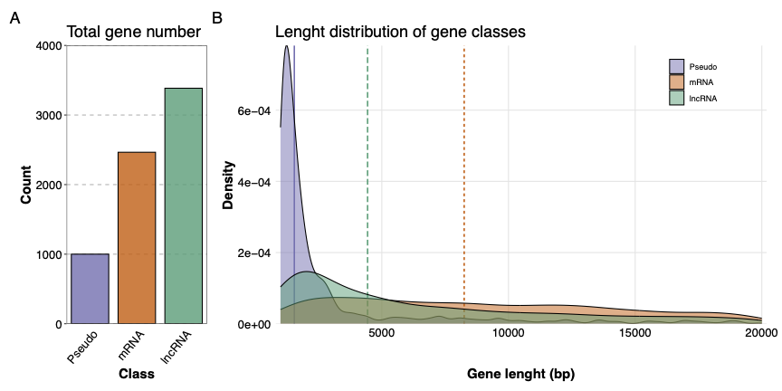

Figure 1: Overview human genes. A: Total number per gene class. B: Gene length distribution per class. Vertical lines represent median gene length per class.

# 5 Differential gene expression

Differential gene expression (DGE) analysis is a process that aims to determine genes which exhibit significant changes in expression levels between different conditions like cell types, disease states, or experimental treatments. Often, these genes are crucial in deciphering the biological factors driving phenotypic differences and can serve as potential biomarkers or therapeutic targets.

## 5.1 Load and prepare data

Download and read in the “deseq2_dummy.txt” dataset from iLearn. It contains test results for 5000 genes from a DGE analysis using the DESeq2 package. Inform yourself about the individual variables of the DESeq2 output. In addition, the table includes normalized RNA-seq counts for the two conditions analyzed (3 replicates each).

After the read-in, select the top 2000 genes according to the average of the normalized count values (highest values).

> **Note**: DESeq2 is a quite popular R software package in the field of bioinformatics. It is primarily employed for the analysis of high-throughput RNA-seq data to identify differentially expressed genes between different experimental conditions.

## 5.2 Plotting

### 5.2.1 Volcano plots

Volcano plots are frequently utilized to present results from a DGE analysis. It is a type of scatterplot that illustrates statistical significance (p-value) against the magnitude of change (fold change), allowing for the rapid visual identification of genes with both large fold changes and high statistical significance. Such genes are often the most biologically important. In a volcano plot, genes with the highest upregulation are positioned to the right, those with the greatest downregulation to the left, and the most statistically significant genes appear at the top.

> **Note**: Genes with an adjusted p-value lower 0.1 are described as significant.

> **Note**: Add a label to all significant genes with a log2 fold change higher than 2.

> **Tip**: There is a ggplot2 extension named “ggrepel” which offers a very intuitive and clean way for labeling individual values of your dataset.

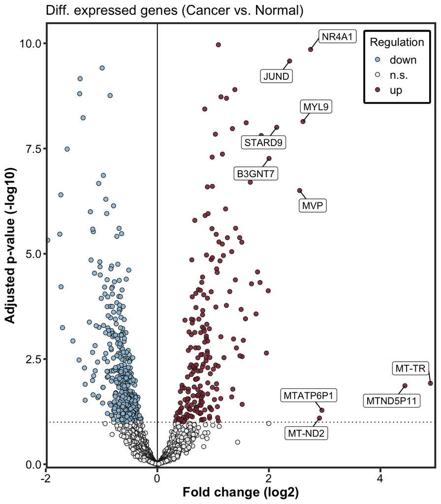

### 5.2.2 Heatmaps

The following graph shows a heatmap of the RNA-seq expression values for the 20 genes with the minimum adjusted p-value. The code for this chart can be found below the image. However, it appears that there are some mistakes in the code, which causes R to output an error.

The last task is simply to change the code so that you get the same heatmap as the one displayed here.

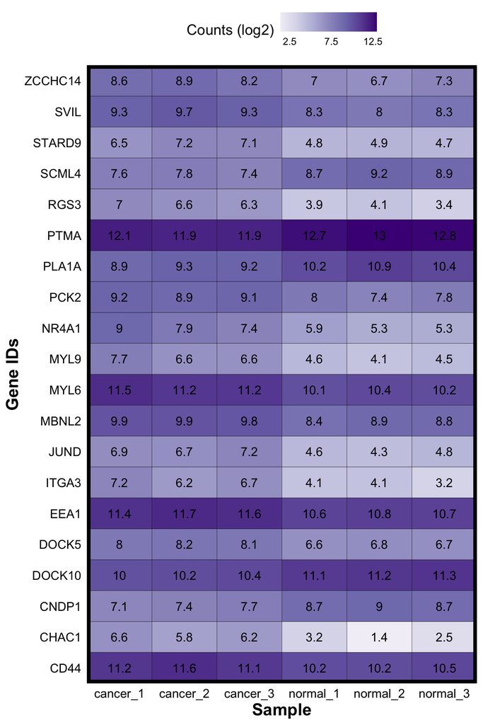

```r
# Take a subsample of the "dummy" DESeq2 output
deseq2_res_f <- deseq2_res %>%
  slice_min(n = 20, order_by = "padj")

# Create the plot
deseq2_res_f %>%
  dplyr::select(gene_id, 9:14) %>%
  pivot_longer(cols = 9:14, names_to = "condition", values_to = "counts") %>%
  ggplot(deseq2_res_f, aes(x = condition, y = gene_id, color = "black", fill = log2(counts), label = round(log2(counts), digits = 2))) +
  geom_tile(color = "black") +
  geom_text() +
  coord_cartesian(expand = c(0,0)) +
  scale_fill_distiller(palette = "Purples") +
  labs(x =  "Sample", y = "Gene IDs", fill = "Counts (log2)") +
  theme_minimal() +
  theme(legend.position = "top",
        legend.ticks = element_blank(),
        title = element_text(size = 13),
        axis.text = element_text(size = 11, colour = "black"),
        axis.title = element_text(size = 15, face = "bold"),
        panel.border = element_rect(size = 3))
```